# Your Digest for Tuesday, Aug 22, 2023 11:59 PM

The heart can't pump enough blood.

```
+ Continued urinary sodium excretion > 30mmol/L (if less than this, consider hypovolaemic hyponatraemia)
+ No adrenal dysfunction
```

# BCR-ABL is the mutation seen in chronic myeloid leukemia.

c-Myc mutations are associated with Burkitt lymphoma.  
P53 mutations are associated with many cancers.

Initially noticed as a cluster of *pneumocystis jirovecii + kaposi sarcoman patients*.

## Acute phase

The HIV virus replicated **within CD4 cells** in the lymph nodes -> lymphadenopathy.  
During the next few weeks, there is massive viral replication and the virus disseminates throughout all body tissues.  
80-90% of all CD4 cells are killed due to infection within the first few weeks. Patient are still undiagnosed at this point.  
Following this phase, the immune system begins to mount a response: This is called **seroconversion**.  
During seroconversion, patient develop flu like / consitutional symptoms.  
During this time, they are highly infective because of the high viral load.  
However, over the next few months, viral load reduces even without ART.

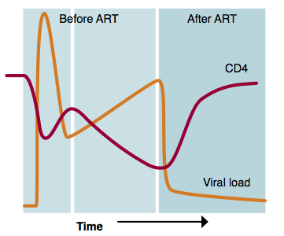

[Source](https://i-base.info/guides/art-in-pictures/the-natural-history-of-hiv-in-detail)  
Historically, people were usually diagnosed in the chronic phase but now more and more people are diagnosed in the acute phase. This is important because starting ART earlier is associated with better prognosis.

ART quickly reduces viral load – by 90% in a few days. Viral load should then become undetectable within 1 to 3 months.  
Overall asymptomatic (+/- lymphadenopathy ) but may have *increasing frequency of some types of infection*.

# Causes of pulseless electrical activity

Pathogenesis : the cardiac muscle is unable to produced a conctraction which ejects enough blood to produce a pulse.  
Conditions causing sudden changes in preload, afterload or contractility can cause PEA.

- **Preload reduction** -> severe hypovolemia, obstructing pulmonary embolus, cardiac tamponade.
- Decreased contractility -> commonest cause for PEA is **hypoxia** (insuffient ATP for contraction), hypocalcemia (calcium is required for sliding filament contraction),
- Increased afterload is very unlikle to cause PEA
- The H's and T's also are all causes of PEA.  
  [Source](https://emedicine.medscape.com/article/161080-overview#a5)

## "3 and 3 rule of Desbiens"

**3 commonest causes of PEA**:

1. Sever hypovolemia
2. Pump failure - *massive MI* or severe heart failure.
3. obstruction of flow
   - **3 main causes of obstruction of circulation**:
     1. Tension pneumothorax
     2. Cardiac tamponade
     3. Massive pulmonary embolus

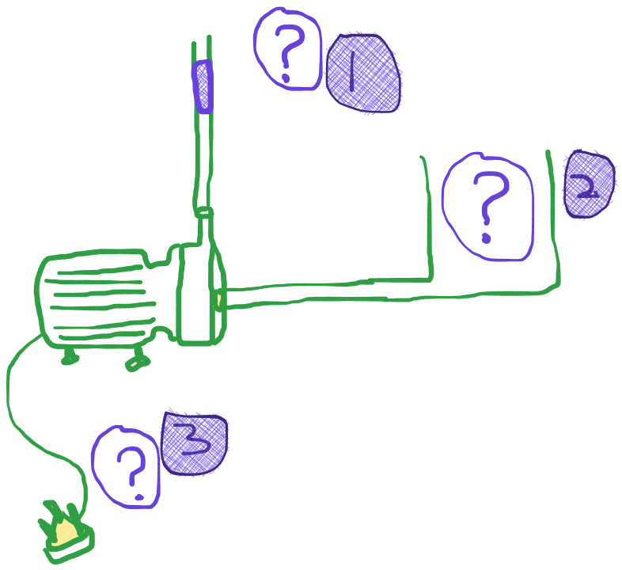

**Definition:** In terms of haemodynamics, the heart cannot pump enough blood to meet the needs of the body or can do so only under *high filling pressures*.

##### Mechanisms of action

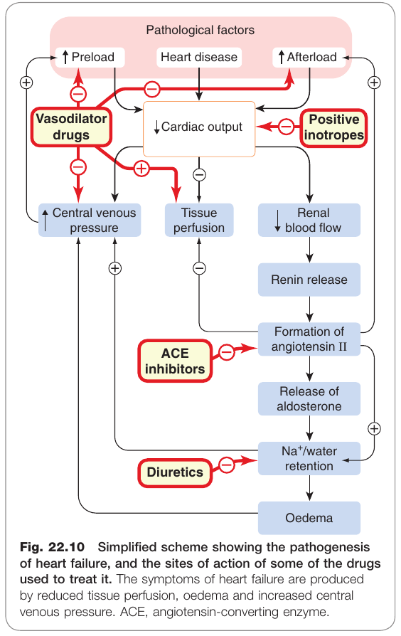

**ACEi** -> Not simply due to reduction in afterload and preload by vasolidation; Possibly by limiting pathological cardiac remodeling. Bradykinin (which is increased by ACEi "*produces coronary and arterial vasodilation and improves LV relaxation and contractile performance*".

#2022GM-MAY Q01  
**Beta blockers**: reducing detrimental effects of catecholamine stimulation (i.e increased heart rate, increased oxygen demand).  
Reduced afterload;  
While beta blockers *acutely* reduce cardiac function due to negative inotropy and negative chronotropy, when given *chronically*, they can improve systolic function and alter geometry to improve LV wall stress.  
Reduced heart rate reduces oxygen demand and improved myocardial perfusion.

**MRA**: Diuretic and BP lowering effects + blockage of deleterious effects of aldosterone on the heart.

**SGLT2 inhibitors**: multiple mechanisms proposed.

# Heart failure with preserved ejection fraction.

==Is HFpEF the same thing as 'diastolic failure'?==

Diastolic dysfunction = abnormal cardiac relaxtion = stiffness = abnormal filling.  
Usually, systolic and diastolic dysfunction occur simultaneously.

HFpEF characteristically has

1. **normal LV ejection fraction**.
2. Normal left ventricular end diastolic volume
3. **abnormal diastolic function** usually with LV **concentric** remodeling or hypertrophy.

The main difference in LV morphology is

1. HFrEF: decreased ventricular mass : volume ratio
2. HFpEF: increased ventricular mass to volume ratio.

*There is technically a difference between diastolic dysfunction and HFpEF*:

1. Impaired relaxation / stiffness / abnormal filling can occur without symptoms of heart failure => 'diastolic dysfunction'.
2. Diastolic dysfunction **+ clinical features of heart failure** => **HFpEF**.

HFrEF = EF < 40%;  
HRpEF = EF > 50%;

==If so, what causes HFpEF? Are the the same things that cause ventricular hypertrophy?==

- the leading risk factors for HFpEF are older age, systemic hypertension, obesity, sedentary lifestyle, and myocardial ischemia.

==Which ventricle fails in HFpEF?==  
Chronic HF is divided into HFrEF and HFpEF based on **left ventricular** ejection fraction.  
Pulmonary hypertension is a known complication of HFpEF and presumably, can *lead to* RV failure.

==How are the symptoms of HFpEF different from HFrEF?==

> The clinical manifestations of HFpEF are generally the same as those for other forms of HF

| Symptoms and signs of heart failure | Percentage of patients (%) |
| --- | --- |
| DOE | 98 |
| Fatigue | 59 |
| Edema | 45 |
| Orthopnea | 22 |
| JVD | 17 |
| Rales | 11 |
| PND | 7.60 |
| Dyspnea at rest | 4.60 |

**Stages** of heart failure (define by the AHA)

[output not shown]

**NYHA** classes of heart failure

| Class | Symptoms |
| --- | --- |
| I | **No limitation** of physical activity. Ordinary physical activity *does not cause undue fatigue*, palpitation or shortness of breath. |
| II | **Slight limitation** of physical activity. Comfortable at rest. *Ordinary physical* activity results in fatigue, palpitation, shortness of breath or chest pain. |
| III | **Marked limitation** of physical activity. Comfortable at rest. *Less than ordinary* activity causes fatigue, palpitation, shortness of breath or chest pain. |
| IV | **Symptoms of heart failure at rest**. *Any physical activity* causes further discomfort. |

==What are the options for management of HFpEF?==

## Pharmacotherapy of heart failure with preserved ejection fraction

Goals of treatment:

1. reduce symptoms
2. reduce hospital admission
3. improve functional status.

**Preferred pharmacotherapies:**

- loop diuretics for initial therapy
- **sodium-glucose co-transporter 2 (SGLT2) inhibitor**
- a **mineralocorticoid receptor antagonist** (MRA) (eg Spironolactone)
- SGLT2 inhibitors and MRAs reduce the risk of hospitalization.
- The following agents **are not routinely used** because they have not been proven to have benefits in HFpEF!
  - ARNI - sacubitril-valsartan,
  - angiotensin II receptor blockers [ARBs] (eg. Losartan),
  - angiotensin converting enzyme [ACE] inhibitors,
  - calcium channel blockers [CCBs]
  - Beta blockers